# Analysis of MS Methods when using TMT Samples

Christopher Hughes

### Description

This file contains the code for processing the search and quantification output files from the *E. coli* samples spiked with synthetic peptides. **These data were used to make portions of Figure 3, S-8, S-9, S-10, S-11, S-12, S-13.**

- MGF files were generated using RawQuant.
- The data were searched using SearchCLI and PeptideShakerCLI.
- Raw files were quantified with RawQuant.

### Analysis

First call the required libraries.

```r
library(Biostrings)
library(dplyr)
library(ggplot2)
library(RColorBrewer)
library(cowplot)
library(reshape)
library(data.table)
library(viridis)
```

Next we want to make an index based on our search database that we can use to add descriptive data to our search result later on.

```r
####
ecoliDB = readAAStringSet('/projects/ptx_analysis/chughes/databases/oct2017/uniprot_ecoli-crap-spike31907-oct2017-FWD.fasta')
#make an annotation index from yeastDB
ecoliIndex = data.frame('meta' = names(ecoliDB))
ecoliIndex$accession = sub(".*?\\|(.*?)\\|.*", "\\1", ecoliIndex$meta) #grab the accession
ecoliIndex$gene = sub(".*?GN=(.*?) .*", "\\1", ecoliIndex$meta) #grab the gene name
ecoliIndex$species = sub(".*?OS=(.*?) [GP].*", "\\1", ecoliIndex$meta) #grab the species
ecoliIndex = ecoliIndex[,2:4]
```

Now we can go ahead and grab the locations identification and quantification data we will use in the analysis.

```r
#find the files of interest
##PSM Files
ms3_psm_files = list.files('/projects/ptx_analysis/chughes/projects-current/raw-quant/tmt-methods/reports-output/ms3', pattern='*Default_PSM_Report.txt',full.names=TRUE) #psms files from SearchCLI and PeptideShaker, ms3 only
ms2_psm_files = list.files('/projects/ptx_analysis/chughes/projects-current/raw-quant/tmt-methods/reports-output/ms2', pattern='*Default_PSM_Report.txt',full.names=TRUE) #psms files from SearchCLI and PeptideShaker, ms2 only
##MS3 Quant files
ms3_quant_files = list.files('/projects/ptx_analysis/chughes/projects-current/raw-quant/tmt-methods/quant-output/ms3', pattern='*QuantData.txt',full.names=TRUE) #quant files from RawScan algorithm, ms3 only
ms2_quant_files = list.files('/projects/ptx_analysis/chughes/projects-current/raw-quant/tmt-methods/quant-output/ms2', pattern='*QuantData.txt',full.names=TRUE) #quant files from RawScan algorithm, ms2 only
##MS2 Parse files
ms3_ms2parse_files = list.files('/projects/ptx_analysis/chughes/projects-current/raw-quant/tmt-methods/quant-output/ms3', pattern='*MS2ParseData.txt',full.names=TRUE) #ms2 parse files from RawScan algorithm, ms3 only
ms2_ms2parse_files = list.files('/projects/ptx_analysis/chughes/projects-current/raw-quant/tmt-methods/quant-output/ms2', pattern='*MS2ParseData.txt',full.names=TRUE) #ms2 parse files from RawScan algorithm, ms2 only
##MS1 Parse files
ms3_ms1parse_files = list.files('/projects/ptx_analysis/chughes/projects-current/raw-quant/tmt-methods/quant-output/ms3', pattern='*MS1ParseData.txt',full.names=TRUE) #ms1 parse files from RawScan algorithm, ms3 only
ms2_ms1parse_files = list.files('/projects/ptx_analysis/chughes/projects-current/raw-quant/tmt-methods/quant-output/ms2', pattern='*MS1ParseData.txt',full.names=TRUE) #ms1 parse files from RawScan algorithm, ms2 only
##MS3 ion match files
ms3_ionmeta_files = list.files('/projects/ptx_analysis/chughes/projects-current/raw-quant/tmt-methods/reports-output/ms3', pattern='*MS2_Fragment_Meta.txt',full.names=TRUE) #ion match files from RawScan algorithm, ms3 only
ms3_ionsignal_files = list.files('/projects/ptx_analysis/chughes/projects-current/raw-quant/tmt-methods/reports-output/ms3', pattern='*MS2_Fragment_Ions.txt',full.names=TRUE) #ion match files from RawScan algorithm, ms3 only
```

Look first to see whether the notch has been fixed in the lastest software update from Thermo.

```r
quant_new = read.table('/projects/ptx_analysis/chughes/projects-current/raw-quant/tmt-methods/quant-output/ms3/ch_29Sept2017_eColi-31907_TMT11_4e5-120_1_QuantData.txt', header=TRUE, sep='\t') #grab one of the data files
notch_plot = ggplot(melt(quant_new[,32:42]), aes(log10(value))) +
  geom_histogram(bins=200,colour = 'grey60',alpha = 0.5) +
  labs(x = "log10(SN)", y = 'Count', title = 'TMT Reporter Ion Intensity') +
  scale_x_continuous(limits=c(2,7), breaks=seq(2,7,1))
```

```
Using  as id variables
```

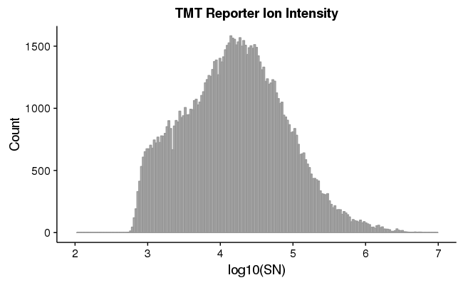

```r
notch_plot #call the plot
save_plot('/projects/ptx_analysis/chughes/projects-current/raw-quant/tmt-methods/Routput/tmt-methods_new-software-notch-plot_ms3.pdf',notch_plot) #save the plot
```

```r
quant_new = read.table('/projects/ptx_analysis/chughes/projects-current/raw-quant/tmt-methods/quant-output/ms2/ch_29Sept2017_eColi-31907_TMT11_MS2_1_QuantData.txt', header=TRUE, sep='\t') #grab one of the data files
notch_plot = ggplot(melt(quant_new[,30:40]), aes(log10(value))) +
  geom_histogram(bins=200,colour = 'grey60',alpha = 0.5) +
  labs(x = "log10(SN)", y = 'Count', title = 'TMT Reporter Ion Intensity') +
  scale_x_continuous(limits=c(2,7), breaks=seq(2,7,1))
```

```
Using  as id variables
```

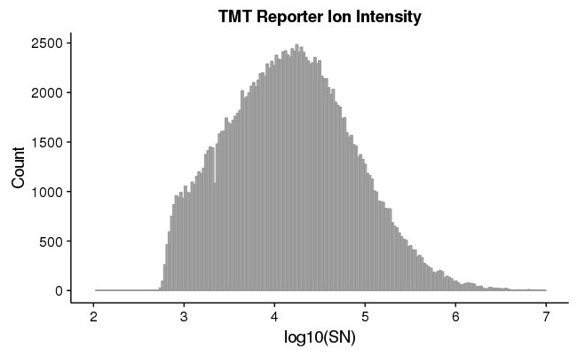

```r
notch_plot #call the plot
save_plot('/projects/ptx_analysis/chughes/projects-current/raw-quant/tmt-methods/Routput/tmt-methods_new-software-notch-plot_ms2.pdf',notch_plot) #save the plot
```

Now we can look at the numbers of MS2 spectra captured across the different data sets.

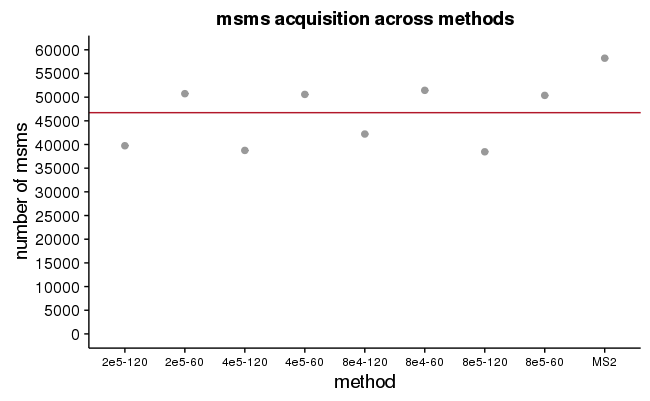

```r
#combine the file read lists for ms2 and ms3
ms2_read_files = c(ms2_ms2parse_files,ms3_ms2parse_files)
ms2_data = data.frame() #data storage object
#iterate over the quantification files to get the numbers of MS2 scans
for (i in 1:length(ms2_read_files)){
  ms2_in = read.table(ms2_read_files[i],header=TRUE,sep='\t') #read in the file
  ms2_in$fraction = sub(".*?TMT11_(.*?)_.*", "\\1", ms2_read_files[i]) #add a fraction column
  ms2_in$replicate = sub(".*?TMT11_(.*?)_MS2.*", "\\1", ms2_read_files[i]) #add a replicate column
  ms2_data = rbind(ms2_data,ms2_in) #bind the data
}
saveRDS(ms2_data,'/projects/ptx_analysis/chughes/projects-current/raw-quant/tmt-methods/Routput/all-tmt-methods-ms2-data.rds') #save the data
msms_table = as.data.frame(table(ms2_data$fraction)) #summarise the data to count the MS2 in each fraction
#plot the data
msms_plot = ggplot(msms_table, aes(x = Var1, y = Freq)) +
  geom_point(colour='grey60',size=2) +
  labs(x = "method", y = 'number of msms', title = 'msms acquisition across methods') +
  theme(axis.text.x = element_text(size = 9)) +
  geom_hline(yintercept=mean(msms_table$Freq,na.rm=TRUE),color = brewer.pal(6,'RdBu')[1]) +
  scale_y_continuous(breaks = seq(0,60000,5000),limits=c(0,60000))
msms_plot #call the plot
save_plot('/projects/ptx_analysis/chughes/projects-current/raw-quant/tmt-methods/Routput/all-tmt-methods-number-of-msms.pdf',msms_plot) #save the plot
```

```r
message('mean number of msms = ',mean(msms_table$Freq,na.rm=TRUE))
```

```
mean number of msms = 46723.4444444444
```

What about the number of quant spectra that pass a threshold of a specific quality? Before we can do this, it would be beneficial to process the quant data into a single frame that we can manipulate.

```r
ms3_quant_data = data.frame() #ms3 data storage object
ms2_quant_data = data.frame() #ms2 data storage object
#iterate over the ms3 quant files
for (i in 1:length(ms3_quant_files)){
  quant_in = read.table(ms3_quant_files[i],header=TRUE,sep='\t') #grab the input file
  #change values that are zero to NA
  quant_in[,11:96][quant_in[,11:96] == 0] = NA
  #rearrange the data frame
  quant_meta = quant_in[,c('PrecursorMass','ScanNumber','MS1ScanNumber','RetentionTime',
                           'PrecursorCharge','MS2IonInjectionTime','MS1Interference',
                           'tmt126_mass','tmt127N_mass','tmt127C_mass','tmt128N_mass','tmt128C_mass','tmt129N_mass','tmt129C_mass',
                           'tmt130N_mass','tmt130C_mass','tmt131N_mass','tmt131C_mass')]
  quant_exprs = quant_in[,c('tmt126_intensity','tmt127N_intensity','tmt127C_intensity','tmt128N_intensity',
                            'tmt128C_intensity','tmt129N_intensity','tmt129C_intensity','tmt130N_intensity',
                            'tmt130C_intensity','tmt131N_intensity','tmt131C_intensity','tmt126_noise','tmt127N_noise',
                            'tmt127C_noise','tmt128N_noise','tmt128C_noise','tmt129N_noise','tmt129C_noise','tmt130N_noise',
                            'tmt130C_noise','tmt131N_noise','tmt131C_noise')]
  #calculate signal to noise
  quant_sn = quant_exprs[,c(1:11)] / quant_exprs[,c(12:22)] #signal-to-noise calculation
  quant_sn$totalIntensity = rowSums(quant_exprs[,1:11],na.rm=TRUE) #total intensity calculation
  quant_sn$totalSN = rowSums(quant_sn[,1:11],na.rm=TRUE) #total signal-to-noise calculation
  quant_sn$totalNoise = rowSums(quant_exprs[,12:22],na.rm=TRUE) #total noise calculation
  quant_sn$totalNA = rowSums(is.na(quant_sn[,1:11])) #information about missing values
  quant_meta$fraction = sub(".*?TMT11_(.*?)_.*", "\\1", ms3_quant_files[i]) #add the fraction column
  quant_meta$replicate = sub(".*?TMT11_(.*?)_Quant.*", "\\1", ms3_quant_files[i]) #add a replicate column
  quant_matrix = cbind(quant_meta,quant_sn) #bind the information and quantification together
  ms3_quant_data = rbind(ms3_quant_data, quant_matrix) #bind into a single frame
  message(i, ' files finished.')
}
#iterate over the ms2 quant files
for (i in 1:length(ms2_quant_files)){
  quant_in = read.table(ms2_quant_files[i],header=TRUE,sep='\t') #grab the input file
  #change values that are zero to NA
  quant_in[,9:74][quant_in[,9:74] == 0] = NA
  #rearrange the data frame
  quant_meta = quant_in[,c('PrecursorMass','ScanNumber','MS1ScanNumber','RetentionTime',
                           'PrecursorCharge','MS2IonInjectionTime','MS1Interference',
                           'tmt126_mass','tmt127N_mass','tmt127C_mass','tmt128N_mass','tmt128C_mass','tmt129N_mass','tmt129C_mass',
                           'tmt130N_mass','tmt130C_mass','tmt131N_mass','tmt131C_mass')]
  quant_exprs = quant_in[,c('tmt126_intensity','tmt127N_intensity','tmt127C_intensity','tmt128N_intensity',
                            'tmt128C_intensity','tmt129N_intensity','tmt129C_intensity','tmt130N_intensity',
                            'tmt130C_intensity','tmt131N_intensity','tmt131C_intensity','tmt126_noise','tmt127N_noise',
                            'tmt127C_noise','tmt128N_noise','tmt128C_noise','tmt129N_noise','tmt129C_noise','tmt130N_noise',
                            'tmt130C_noise','tmt131N_noise','tmt131C_noise')]
  #calculate signal to noise
  quant_sn = quant_exprs[,c(1:11)] / quant_exprs[,c(12:22)] #signal-to-noise calculation
  quant_sn$totalIntensity = rowSums(quant_exprs[,1:11],na.rm=TRUE) #total intensity calculation
  quant_sn$totalSN = rowSums(quant_sn[,1:11],na.rm=TRUE) #total signal-to-noise calculation
  quant_sn$totalNoise = rowSums(quant_exprs[,12:22],na.rm=TRUE) #total noise calculation
  quant_sn$totalNA = rowSums(is.na(quant_sn[,1:11])) #information about missing values
  quant_meta$fraction = sub(".*?TMT11_(.*?)_.*", "\\1", ms2_quant_files[i]) #add the fraction column
  quant_meta$replicate = sub(".*?TMT11_(.*?)_Quant.*", "\\1", ms2_quant_files[i]) #add a replicate column
  quant_matrix = cbind(quant_meta,quant_sn) #bind the information and quantification together
  ms2_quant_data = rbind(ms2_quant_data, quant_matrix) #bind into a single frame
  message(i, ' files finished.')
}
all_quant_data = rbind(ms3_quant_data,ms2_quant_data) #bind the ms3 and ms2 data
#save the data
saveRDS(all_quant_data,'/projects/ptx_analysis/chughes/projects-current/raw-quant/tmt-methods/Routput/tmt-method-testing-quant-data_no-sps.rds')
```

Now that we have the quantification set, we can look at the number of quantification scans passing a quality threshold.

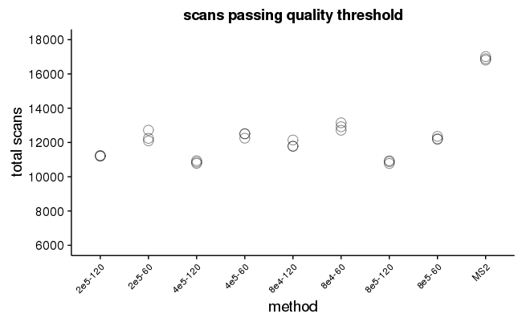

```r
q_set = readRDS('/projects/ptx_analysis/chughes/projects-current/raw-quant/tmt-methods/Routput/tmt-method-testing-quant-data_no-sps.rds') #grab the quantification data
q_set$scan_count = 1 #add an extra column as a counter
q_set = subset(q_set, rowSums(is.na(q_set[,21:31]))<6) #remove scans with more than 50% NA values
q_set = subset(q_set, totalSN>100) #remove scans with a summed signal of less than 100
q_agg <- setDT(q_set)[, lapply(.SD,sum,na.rm=TRUE),by=.(fraction,replicate),.SDcols=c('scan_count')] #collapse by fraction and replicate
setDF(q_agg) # convert back to dataframe
#make an ion metrics plot
scan_plot = ggplot(q_agg, aes(fraction,scan_count,group=fraction)) +
  geom_point(size=4,shape=21,alpha=0.5) +
  theme(axis.text.x = element_text(size = 9)) +
  labs(x = "method", y = 'total scans', title = 'scans passing quality threshold') +
  scale_y_continuous(limits=c(6000,18000),breaks=seq(6000,18000,2000)) +
  theme(axis.text.x = element_text(angle = 45, hjust = 1))
scan_plot #call the plot
save_plot('/projects/ptx_analysis/chughes/projects-current/raw-quant/tmt-methods/Routput/tmt-methods_scan-rates-boxplot.pdf',scan_plot) #save the plot
```

We can also look at the ion metrics.

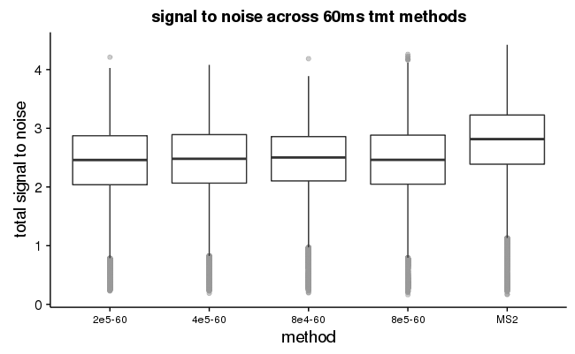

```r
q_set = readRDS('/projects/ptx_analysis/chughes/projects-current/raw-quant/tmt-methods/Routput/tmt-method-testing-quant-data_no-sps.rds') #grab the quantification data
q_60 = subset(q_set, !grepl('120',q_set$fraction)) #get the 60ms data
q_120 = subset(q_set, !grepl('60',q_set$fraction)) #get the 120ms data
#make an ion metrics plot
ion60_plot = ggplot(q_60, aes(fraction,log10(totalSN),group=fraction)) +
  geom_boxplot(outlier.color = 'gray60',outlier.alpha=0.5) +
  theme(axis.text.x = element_text(size = 9)) +
  labs(x = "method", y = 'total signal to noise', title = 'signal to noise across 60ms tmt methods')
ion60_plot #call the plot
save_plot('/projects/ptx_analysis/chughes/projects-current/raw-quant/tmt-methods/Routput/tmt-methods_ion-signal-60-boxplot.pdf',ion60_plot) #save the plot
```

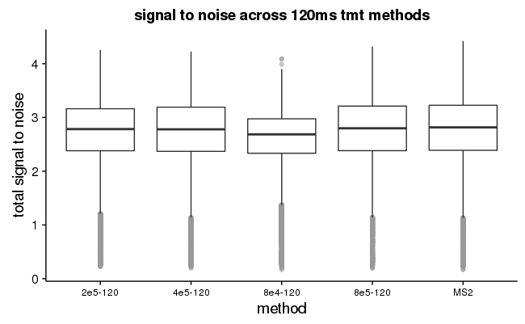

```r
#make an ion metrics plot
ion120_plot = ggplot(q_120, aes(fraction,log10(totalSN),group=fraction)) +
  geom_boxplot(outlier.color = 'gray60',outlier.alpha=0.5) +
  theme(axis.text.x = element_text(size = 9)) +
  labs(x = "method", y = 'total signal to noise', title = 'signal to noise across 120ms tmt methods')
ion120_plot #call the plot
save_plot('/projects/ptx_analysis/chughes/projects-current/raw-quant/tmt-methods/Routput/tmt-methods_ion-signal-120-boxplot.pdf',ion120_plot) #save the plot
```

We can look at how expression ratios look in the ms2 vs. ms2 data. This requires a new type of dataframe with the identifications added.

```r
ms3_id_quant = data.frame() #ms3 data storage object
ms2_id_quant = data.frame() #ms2 data storage object
#iterate over the ms3 files
for (i in 1:length(ms3_psm_files)){
###this first section handles the identification data
  psm_in = read.table(ms3_psm_files[i],header=TRUE,sep='\t') #input file
  psm_f1 = psm_in %>%
    dplyr::select(Protein.s., Sequence, Spectrum.File, Spectrum.Title, m.z, Identification.Charge) %>% #select columns
    dplyr::mutate(Spectrum.Title, scan_num = sub(".*?spectrum (.*?)", "\\1", Spectrum.Title)) %>% #parse out the scan number
    dplyr::mutate(Identification.Charge, id_charge = gsub("[^0-9]", "", Identification.Charge)) %>% #parse out the charge
    dplyr::mutate(Spectrum.Title, fraction = sub(".*?TMT11_(.*?)_.*", "\\1", Spectrum.File)) %>% #parse the fraction
    dplyr::mutate(Spectrum.Title, replicate = sub(".*?TMT11_(.*?)_MGF\\.mgf", "\\1", Spectrum.File)) %>% #parse the fraction
    dplyr::select(Protein.s., Sequence, scan_num, m.z, id_charge, fraction, replicate) %>% #select new columns
    dplyr::mutate(Protein.s., first_accession = sapply(strsplit(as.character(Protein.s.),"\\,"), `[`, 1)) #parse the accession
  #adjust the column names
  colnames(psm_f1) = c('accession_groups','sequence','ScanNumber','id_precursor_mz','id_charge','fraction','replicate','accession')
  psm_f2 = merge(psm_f1,ecoliIndex,by='accession',all.x=TRUE) #add the descriptive data
  psm_f3 = dplyr::filter(psm_f2, !grepl('CONT', accession)) #remove contaminant hits

  ####this second section handles the RawScan quantification data
  quant_in = read.table(ms3_quant_files[i],header=TRUE,sep='\t') #grab the input file
  quant_in[,11:96][quant_in[,11:96] == 0] = NA
  #rearrange the data frame
  quant_meta = quant_in[,c('PrecursorMass','MS2ScanNumber','MS1ScanNumber','RetentionTime',
                           'PrecursorCharge','MS2IonInjectionTime','MS1Interference',
                           'tmt126_mass','tmt127N_mass','tmt127C_mass','tmt128N_mass','tmt128C_mass','tmt129N_mass','tmt129C_mass',
                           'tmt130N_mass','tmt130C_mass','tmt131N_mass','tmt131C_mass')]
  colnames(quant_meta)[2] = 'ScanNumber'
  quant_exprs = quant_in[,c('tmt126_intensity','tmt127N_intensity','tmt127C_intensity','tmt128N_intensity',
                            'tmt128C_intensity','tmt129N_intensity','tmt129C_intensity','tmt130N_intensity',
                            'tmt130C_intensity','tmt131N_intensity','tmt131C_intensity','tmt126_noise','tmt127N_noise',
                            'tmt127C_noise','tmt128N_noise','tmt128C_noise','tmt129N_noise','tmt129C_noise','tmt130N_noise',
                            'tmt130C_noise','tmt131N_noise','tmt131C_noise')]
  #calculate signal to noise
  quant_sn = quant_exprs[,c(1:11)] / quant_exprs[,c(12:22)] #signal-to-noise calculation
  quant_sn$totalIntensity = rowSums(quant_exprs[,1:11],na.rm=TRUE) #total intensity calculation
  quant_sn$totalSN = rowSums(quant_sn[,1:11],na.rm=TRUE) #total signal-to-noise calculation
  quant_sn$totalNoise = rowSums(quant_exprs[,12:22],na.rm=TRUE) #total noise calculation
  quant_sn$totalNA = rowSums(is.na(quant_sn[,1:11])) #information about missing values
  quant_meta$fraction = sub(".*?TMT11_(.*?)_.*", "\\1", ms3_quant_files[i]) #add the fraction column
  quant_meta$replicate = sub(".*?TMT11_(.*?)_Quant.*", "\\1", ms3_quant_files[i]) #add a replicate column
  quant_matrix = cbind(quant_meta,quant_sn) #bind the information and quantification together
  ####this section merges all of the data together
  quant_id = merge(psm_f3,quant_matrix,by=c('ScanNumber','fraction','replicate'),all.x=TRUE) #merge the id and quant data
  ms3_id_quant = rbind(ms3_id_quant,quant_id) #merge with the ongiong data frame
  message('finished ',i,' ms3 files') #output message for tracking progress
}
#iterate over the ms2 files
for (i in 1:length(ms2_psm_files)){
###this first section handles the identification data
  psm_in = read.table(ms2_psm_files[i],header=TRUE,sep='\t') #input file
  psm_f1 = psm_in %>%
    dplyr::select(Protein.s., Sequence, Spectrum.File, Spectrum.Title, m.z, Identification.Charge) %>% #select columns
    dplyr::mutate(Spectrum.Title, scan_num = sub(".*?spectrum (.*?)", "\\1", Spectrum.Title)) %>% #parse out the scan number
    dplyr::mutate(Identification.Charge, id_charge = gsub("[^0-9]", "", Identification.Charge)) %>% #parse out the charge
    dplyr::mutate(Spectrum.Title, fraction = sub(".*?TMT11_(.*?)_.*", "\\1", Spectrum.File)) %>% #parse the fraction
    dplyr::mutate(Spectrum.Title, replicate = sub(".*?TMT11_(.*?)_MGF\\.mgf", "\\1", Spectrum.File)) %>% #parse the fraction
    dplyr::select(Protein.s., Sequence, scan_num, m.z, id_charge, fraction, replicate) %>% #select new columns
    dplyr::mutate(Protein.s., first_accession = sapply(strsplit(as.character(Protein.s.),"\\,"), `[`, 1)) #parse the accession
  #adjust the column names
  colnames(psm_f1) = c('accession_groups','sequence','ScanNumber','id_precursor_mz','id_charge','fraction','replicate','accession')
  psm_f2 = merge(psm_f1,ecoliIndex,by='accession',all.x=TRUE) #add the descriptive data
  psm_f3 = dplyr::filter(psm_f2, !grepl('CONT', accession)) #remove contaminant hits

  ####this second section handles the RawScan quantification data
  quant_in = read.table(ms2_quant_files[i],header=TRUE,sep='\t') #grab the input file
  quant_in[,9:74][quant_in[,9:74] == 0] = NA
  #rearrange the data frame
  quant_meta = quant_in[,c('PrecursorMass','ScanNumber','MS1ScanNumber','RetentionTime',
                           'PrecursorCharge','MS2IonInjectionTime','MS1Interference',
                           'tmt126_mass','tmt127N_mass','tmt127C_mass','tmt128N_mass','tmt128C_mass','tmt129N_mass','tmt129C_mass',
                           'tmt130N_mass','tmt130C_mass','tmt131N_mass','tmt131C_mass')]
  quant_exprs = quant_in[,c('tmt126_intensity','tmt127N_intensity','tmt127C_intensity','tmt128N_intensity',
                            'tmt128C_intensity','tmt129N_intensity','tmt129C_intensity','tmt130N_intensity',
                            'tmt130C_intensity','tmt131N_intensity','tmt131C_intensity','tmt126_noise','tmt127N_noise',
                            'tmt127C_noise','tmt128N_noise','tmt128C_noise','tmt129N_noise','tmt129C_noise','tmt130N_noise',
                            'tmt130C_noise','tmt131N_noise','tmt131C_noise')]
  #calculate signal to noise
  quant_sn = quant_exprs[,c(1:11)] / quant_exprs[,c(12:22)] #signal-to-noise calculation
  quant_sn$totalIntensity = rowSums(quant_exprs[,1:11],na.rm=TRUE) #total intensity calculation
  quant_sn$totalSN = rowSums(quant_sn[,1:11],na.rm=TRUE) #total signal-to-noise calculation
  quant_sn$totalNoise = rowSums(quant_exprs[,12:22],na.rm=TRUE) #total noise calculation
  quant_sn$totalNA = rowSums(is.na(quant_sn[,1:11])) #information about missing values
  quant_meta$fraction = sub(".*?TMT11_(.*?)_.*", "\\1", ms2_quant_files[i]) #add the fraction column
  quant_meta$replicate = sub(".*?TMT11_(.*?)_Quant.*", "\\1", ms2_quant_files[i]) #add a replicate column
  quant_matrix = cbind(quant_meta,quant_sn) #bind the information and quantification together
  ####this section merges all of the data together
  quant_id = merge(psm_f3,quant_matrix,by=c('ScanNumber','fraction','replicate'),all.x=TRUE) #merge the id and quant data
  ms2_id_quant = rbind(ms2_id_quant,quant_id) #merge with the ongiong data frame
  message('finished ',i,' ms2 files') #output message for tracking progress
}
ms3_ms2_all = rbind(ms3_id_quant,ms2_id_quant) #bind the data together
saveRDS(ms3_ms2_all,'/projects/ptx_analysis/chughes/projects-current/raw-quant/tmt-methods/Routput/tmt-method-testing-id-quant-ms3-ms2_data.rds') #save the data
```

Now we can look at the ratios of ms2 and ms3 data.

```r
id_quant = readRDS('/projects/ptx_analysis/chughes/projects-current/raw-quant/tmt-methods/Routput/tmt-method-testing-id-quant-ms3-ms2_data.rds')
#choose one of the ms3 runs and plot the ratios across the spike and ecoli channels
#first the spike peptides
spikes = id_quant[grepl('SPIKE_PEPS',id_quant$species) & (id_quant$fraction == '2e5-120'),] #grab the spike peptides from 2e5_120
spikes[,28:38] = apply(spikes[,28:38],2,function(x) (x/spikes$totalSN)*14) #14 here is the sum of all TMT values
spike_ratio_plot = ggplot(melt(spikes[,c(28:38)]), aes(variable,value)) +
  geom_boxplot(outlier.color = 'gray60',outlier.alpha=0.5, outlier.shape=1) +
  theme(axis.text.x = element_text(size = 9)) +
  labs(x = "method", y = 'tmt signal', title = 'ms3 spike peptide signal across channels') +
  geom_hline(yintercept=2,color=brewer.pal(6,'RdBu')[1]) +
  geom_hline(yintercept=1,color=brewer.pal(6,'RdBu')[1]) +
  geom_hline(yintercept=3,color=brewer.pal(6,'RdBu')[1]) +
  scale_y_continuous(limits=c(0,5),breaks=seq(0,5,0.5))
```

```
Using  as id variables
```

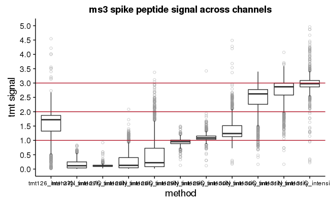

```r
spike_ratio_plot #call the plot
save_plot('/projects/ptx_analysis/chughes/projects-current/raw-quant/tmt-methods/Routput/tmt-methods_spike-ms3-all-channels-boxplot.pdf',spike_ratio_plot) #save the plot
```

```r
#now the ecoli peptides
ecoli = id_quant[grepl('coli',id_quant$species) & (id_quant$fraction == '2e5-120'),] #grab the spike peptides from 2e5_120
ecoli[,28:38] = apply(ecoli[,28:38],2,function(x) (x/ecoli$totalSN)*21) #21 here is the sum of all TMT values
ecoli_ratio_plot = ggplot(melt(ecoli[,c(28:38)]), aes(variable,value)) +
  geom_boxplot(outlier.color = 'gray60',outlier.alpha=0.5, outlier.shape=1) +
  theme(axis.text.x = element_text(size = 9)) +
  labs(x = "method", y = 'tmt signal', title = 'ms3 ecoli peptide signal across channels') +
  geom_hline(yintercept=4,color=brewer.pal(6,'RdBu')[1]) +
  geom_hline(yintercept=1,color=brewer.pal(6,'RdBu')[1]) +
  geom_hline(yintercept=2,color=brewer.pal(6,'RdBu')[1]) +
  scale_y_continuous(limits=c(0,6),breaks=seq(0,6,0.5))
```

```
Using  as id variables
```

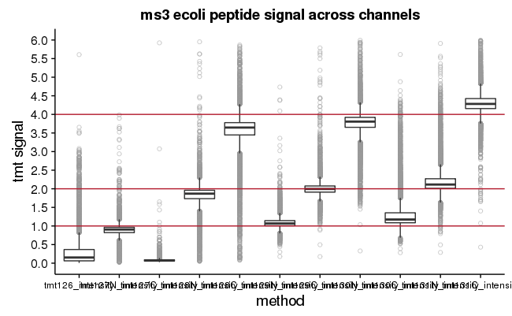

```r
ecoli_ratio_plot #call the plot
save_plot('/projects/ptx_analysis/chughes/projects-current/raw-quant/tmt-methods/Routput/tmt-methods_ecoli-ms3-all-channels-boxplot.pdf',ecoli_ratio_plot) #save the plot
```

```r
#now do the same for the MS2 runs
#first the spike peptides
spikes = id_quant[grepl('SPIKE_PEPS',id_quant$species) & (id_quant$fraction == 'MS2'),] #grab the spike peptides from MS2
spikes[,28:38] = apply(spikes[,28:38],2,function(x) (x/spikes$totalSN)*14) #14 here is the sum of all TMT values
spike_ratio_plot = ggplot(melt(spikes[,c(28:38)]), aes(variable,value)) +
  geom_boxplot(outlier.color = 'gray60',outlier.alpha=0.5, outlier.shape=1) +
  theme(axis.text.x = element_text(size = 9)) +
  labs(x = "method", y = 'tmt signal', title = 'ms2 spike peptide signal across channels') +
  geom_hline(yintercept=2,color=brewer.pal(6,'RdBu')[1]) +
  geom_hline(yintercept=1,color=brewer.pal(6,'RdBu')[1]) +
  geom_hline(yintercept=3,color=brewer.pal(6,'RdBu')[1]) +
  scale_y_continuous(limits=c(0,5),breaks=seq(0,5,0.5))
```

```
Using  as id variables
```

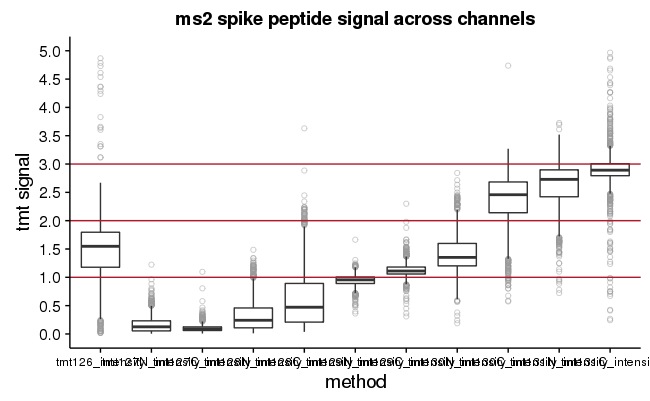

```r
spike_ratio_plot #call the plot
save_plot('/projects/ptx_analysis/chughes/projects-current/raw-quant/tmt-methods/Routput/tmt-methods_spike-ms2-all-channels-boxplot.pdf',spike_ratio_plot) #save the plot
```

```r
#now the ecoli peptides
ecoli = id_quant[grepl('coli',id_quant$species) & (id_quant$fraction == 'MS2'),] #grab the spike peptides from MS2
ecoli[,28:38] = apply(ecoli[,28:38],2,function(x) (x/ecoli$totalSN)*21) #21 here is the sum of all TMT values
ecoli_ratio_plot = ggplot(melt(ecoli[,c(28:38)]), aes(variable,value)) +
  geom_boxplot(outlier.color = 'gray60',outlier.alpha=0.5, outlier.shape=1) +
  theme(axis.text.x = element_text(size = 9)) +
  labs(x = "method", y = 'tmt signal', title = 'ms2 ecoli peptide signal across channels') +
  geom_hline(yintercept=4,color=brewer.pal(6,'RdBu')[1]) +
  geom_hline(yintercept=1,color=brewer.pal(6,'RdBu')[1]) +
  geom_hline(yintercept=2,color=brewer.pal(6,'RdBu')[1]) +
  scale_y_continuous(limits=c(0,6),breaks=seq(0,6,0.5))
```

```
Using  as id variables
```

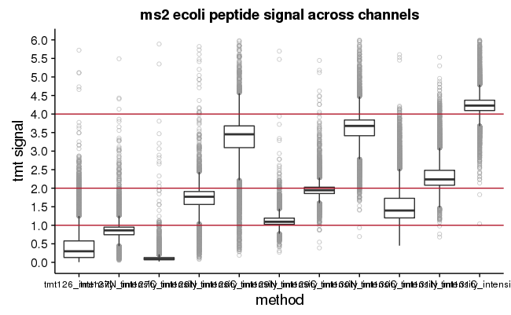

```r
ecoli_ratio_plot #call the plot
save_plot('/projects/ptx_analysis/chughes/projects-current/raw-quant/tmt-methods/Routput/tmt-methods_ecoli-ms2-all-channels-boxplot.pdf',ecoli_ratio_plot) #save the plot
```

How can we quantify this interference?

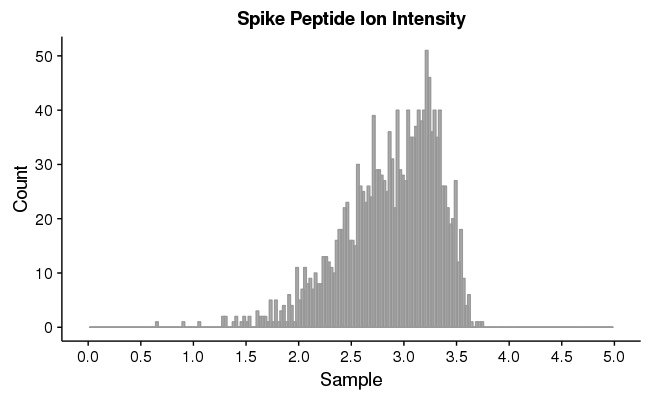

```r
id_quant = readRDS('/projects/ptx_analysis/chughes/projects-current/raw-quant/tmt-methods/Routput/tmt-method-testing-id-quant-ms3-ms2_data.rds')
spikes = subset(id_quant, grepl('SPIKE_PEPS', id_quant$species) & grepl('2e5-120', id_quant$fraction)) #keep only spike peptides
#first we can plot the distrubition of spike intensities
spike_dist = ggplot(spikes, aes(log10(totalSN))) +
  geom_histogram(bins=200,colour = 'grey60',alpha = 0.5) +
  labs(x = "Sample", y = 'Count', title = 'Spike Peptide Ion Intensity') +
  scale_x_continuous(limits=c(0,5),breaks=seq(0,5,0.5))
spike_dist #call the plot
save_plot('/projects/ptx_analysis/chughes/projects-current/raw-quant/tmt-methods/Routput/tmt-methods_spike-distribution.pdf',spike_dist) #save the plot
```

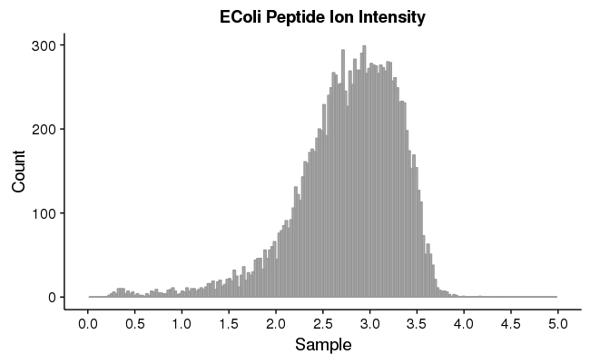

```r
#fnow get the distribution of regular peptides
ecoli = subset(id_quant, grepl('coli', id_quant$species) & grepl('2e5-120', id_quant$fraction)) #keep only ecoli peptides
ecoli_dist = ggplot(ecoli, aes(log10(totalSN))) +
  geom_histogram(bins=200,colour = 'grey60',alpha = 0.5) +
  labs(x = "Sample", y = 'Count', title = 'EColi Peptide Ion Intensity') +
  scale_x_continuous(limits=c(0,5),breaks=seq(0,5,0.5))
ecoli_dist #call the plot
save_plot('/projects/ptx_analysis/chughes/projects-current/raw-quant/tmt-methods/Routput/tmt-methods_ecoli-distribution.pdf',ecoli_dist) #save the plot
```

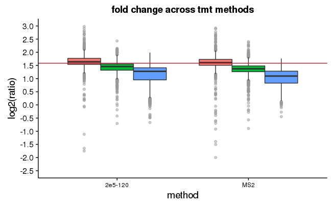

```r
#now look at the quality of the ratios
spikes = subset(id_quant, grepl('SPIKE_PEPS', id_quant$species) & grepl('2e5-120', id_quant$fraction) |  grepl('SPIKE_PEPS', id_quant$species) & grepl('MS2', id_quant$fraction)) #keep only spike peptides
spikes$channel1 = log2(spikes$tmt131C_intensity / spikes$tmt129N_intensity)
spikes$channel2 = log2(spikes$tmt131C_intensity / spikes$tmt129C_intensity)
spikes$channel3 = log2(spikes$tmt131C_intensity / spikes$tmt130N_intensity)
#make a boxplot of the spike data
spike_plot = ggplot(melt(spikes[,c(2,43:45)]), aes(fraction,value)) +
  geom_boxplot(aes(fill=variable), outlier.color = 'gray60',outlier.alpha=0.5) +
  theme(axis.text.x = element_text(size = 9)) +
  labs(x = "method", y = 'log2(ratio)', title = 'fold change across tmt methods') +
  geom_hline(yintercept=log2(3),color=brewer.pal(6,'RdBu')[1]) +
  scale_y_continuous(limits=c(-2.5,3), breaks=seq(-2.5,3,0.5)) +
  theme(legend.position="none")
spike_plot #call the plot
save_plot('/projects/ptx_analysis/chughes/projects-current/raw-quant/tmt-methods/Routput/tmt-methods_spike-ratios-boxplot.pdf',spike_plot) #save the plot
```

So it is quite clear that the magnitude of peptide that is actually spiked really dictates the amount of interference that is observed. So can we derive some sort of filter that really cleans this up? Or find out the primary driver?

Look at MS1 interference with the ratio quality in MS2 vs. MS3.

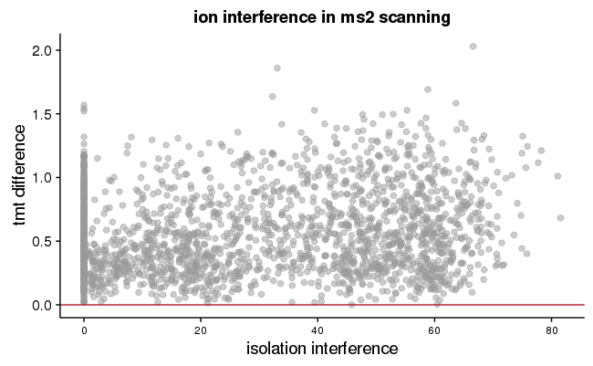

```r
id_quant = readRDS('/projects/ptx_analysis/chughes/projects-current/raw-quant/tmt-methods/Routput/tmt-method-testing-id-quant-ms3-ms2_data.rds')
spikes = subset(id_quant, grepl('SPIKE_PEPS', id_quant$species)) #keep only spike peptides
spikes$channel3 = log2(spikes$tmt131C_intensity / spikes$tmt130N_intensity) #this is the channel with the highest interference
spikes$difference = abs(log2(3) - spikes$channel3) #get the difference from expected
ms2_spikes = subset(spikes, fraction == 'MS2') #get the ms2 data
ms3_spikes = subset(spikes, fraction == '2e5-120') #get the ms3 data
#plot the MS1 inferference for MS2
ms2_quality = ggplot(ms2_spikes, aes(MS1Interference,difference)) +
  geom_point(size=2,alpha=0.5,colour='grey60') +
  theme(axis.text.x = element_text(size = 9)) +
  labs(x = "isolation interference", y = 'tmt difference', title = 'ion interference in ms2 scanning') +
  geom_hline(yintercept = 0,color=brewer.pal(6,'RdBu')[1])
ms2_quality #call the plot
save_plot('/projects/ptx_analysis/chughes/projects-current/raw-quant/tmt-methods/Routput/tmt-methods_MS2-quality-channel3.pdf',ms2_quality) #save the plot
```

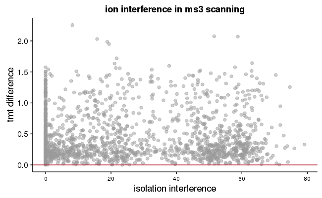

```r
#plot the MS1 inferference for MS3
ms3_quality = ggplot(ms3_spikes, aes(MS1Interference,difference)) +
  geom_point(size=2,alpha=0.5,colour='grey60') +
  theme(axis.text.x = element_text(size = 9)) +
  labs(x = "isolation interference", y = 'tmt difference', title = 'ion interference in ms3 scanning') +
  geom_hline(yintercept = 0,color=brewer.pal(6,'RdBu')[1])
ms3_quality #call the plot
save_plot('/projects/ptx_analysis/chughes/projects-current/raw-quant/tmt-methods/Routput/tmt-methods_MS3-quality-channel3.pdf',ms3_quality) #save the plot
```

```r
message(cor(ms2_spikes$totalSN,ms2_spikes$channel3,use='pairwise.complete.obs'),' in ms2')
```

```
0.319928702530946 in ms2
```

```r
message(cor(ms3_spikes$totalSN,ms3_spikes$channel3,use='pairwise.complete.obs'),' in ms3')
```

```
0.34311476399356 in ms3
```

So a small correlation there. Clear from observing the plot that the difference from the expected value is not dependent on the values in the MS1 interference calculation.

What about the ion intensity?

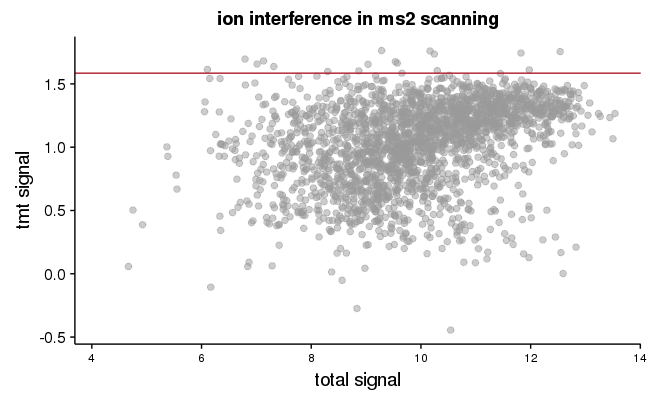

```r
id_quant = readRDS('/projects/ptx_analysis/chughes/projects-current/raw-quant/tmt-methods/Routput/tmt-method-testing-id-quant-ms3-ms2_data.rds')
spikes = subset(id_quant, grepl('SPIKE_PEPS', id_quant$species)) #keep only spike peptides
spikes$channel3 = log2(spikes$tmt131C_intensity / spikes$tmt130N_intensity) #again use the most interfered with channel
spikes$difference = abs(log2(3) - spikes$channel3) #get the difference from expected
ms2_spikes = subset(spikes, fraction == 'MS2') #get the ms2 data
ms3_spikes = subset(spikes, fraction == '2e5-120') #get the ms3 data
#plot the MS1 inferference for MS2
ms2_quality = ggplot(ms2_spikes, aes(log2(totalSN),channel3)) +
  geom_point(size=2,alpha=0.5,colour='grey60') +
  theme(axis.text.x = element_text(size = 9)) +
  labs(x = "total signal", y = 'tmt signal', title = 'ion interference in ms2 scanning') +
  geom_hline(yintercept = log2(3),color=brewer.pal(6,'RdBu')[1])
ms2_quality #call the plot
save_plot('/projects/ptx_analysis/chughes/projects-current/raw-quant/tmt-methods/Routput/tmt-methods_MS2-intensity-channel3.pdf',ms2_quality) #save the plot
```

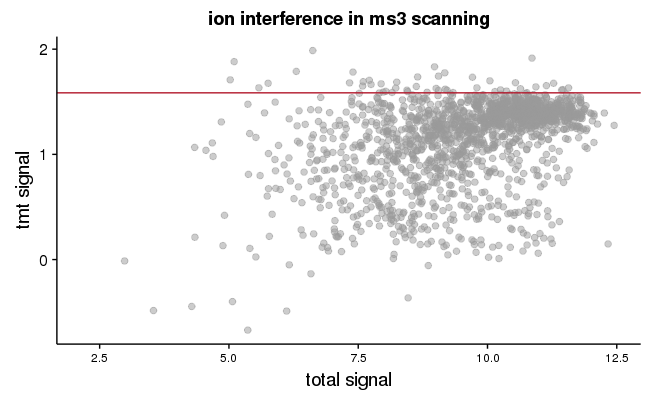

```r
#plot the MS1 inferference for MS3
ms3_quality = ggplot(ms3_spikes, aes(log2(totalSN),channel3)) +
  geom_point(size=2,alpha=0.5,colour='grey60') +
  theme(axis.text.x = element_text(size = 9)) +
  labs(x = "total signal", y = 'tmt signal', title = 'ion interference in ms3 scanning') +
  geom_hline(yintercept = log2(3),color=brewer.pal(6,'RdBu')[1])
ms3_quality #call the plot
save_plot('/projects/ptx_analysis/chughes/projects-current/raw-quant/tmt-methods/Routput/tmt-methods_MS3-intensity-channel3.pdf',ms3_quality) #save the plot
```

```r
message(cor(log2(ms2_spikes$totalSN),ms2_spikes$channel3,use='pairwise.complete.obs'),' in ms2')
```

```
0.347139665798389 in ms2
```

```r
message(cor(log2(ms3_spikes$totalSN),ms3_spikes$channel3,use='pairwise.complete.obs'),' in ms3')
```

```
0.402604603372028 in ms3
```

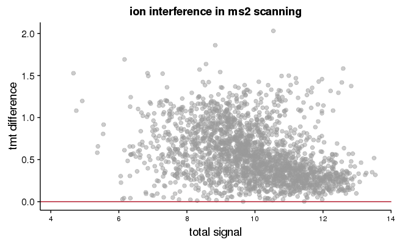

```r
#plot the differences
ms2_quality = ggplot(ms2_spikes, aes(log2(totalSN),difference)) +
  geom_point(size=2,alpha=0.5,colour='grey60') +
  theme(axis.text.x = element_text(size = 9)) +
  labs(x = "total signal", y = 'tmt difference', title = 'ion interference in ms2 scanning') +
  geom_hline(yintercept = 0,color=brewer.pal(6,'RdBu')[1])
ms2_quality #call the plot
save_plot('/projects/ptx_analysis/chughes/projects-current/raw-quant/tmt-methods/Routput/tmt-methods_MS2-difference-channel3.pdf',ms2_quality) #save the plot
```

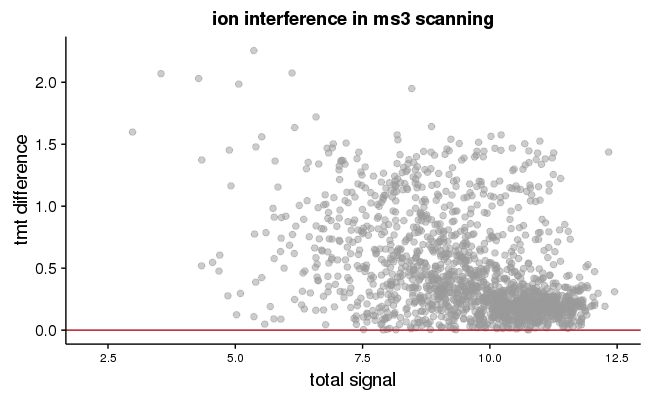

```r
ms3_quality = ggplot(ms3_spikes, aes(log2(totalSN),difference)) +
  geom_point(size=2,alpha=0.5,colour='grey60') +
  theme(axis.text.x = element_text(size = 9)) +
  labs(x = "total signal", y = 'tmt difference', title = 'ion interference in ms3 scanning') +
  geom_hline(yintercept = 0,color=brewer.pal(6,'RdBu')[1])
ms3_quality #call the plot
save_plot('/projects/ptx_analysis/chughes/projects-current/raw-quant/tmt-methods/Routput/tmt-methods_MS3-difference-channel3.pdf',ms3_quality) #save the plot
```

```r
message(cor(log2(ms2_spikes$totalSN),ms2_spikes$difference,use='pairwise.complete.obs'),' in ms2')
```

```
-0.350559838206138 in ms2
```

```r
message(cor(log2(ms3_spikes$totalSN),ms3_spikes$difference,use='pairwise.complete.obs'),' in ms3')
```

```
-0.420675368974275 in ms3
```

The correlation again here is not that great, albeit better than the MS1 Isolation Interference. Looking at the plot, it is clear that more of the ions with a large difference are found at low intensity, despite the correlation.

We should calculate the actual variation of these values.

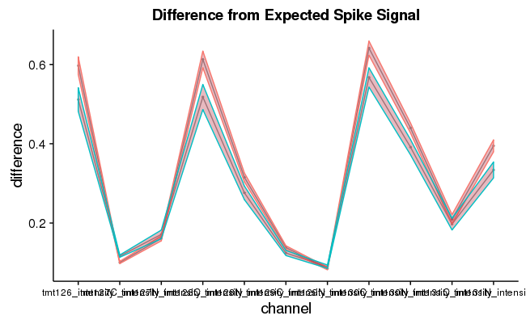

```r
id_quant = readRDS('/projects/ptx_analysis/chughes/projects-current/raw-quant/tmt-methods/Routput/tmt-method-testing-id-quant-ms3-ms2_data.rds')
#choose one of the ms3 runs and calculate the variation across the channels
#first the spike peptides
spikes = id_quant[grepl('SPIKE_PEPS',id_quant$species) & (id_quant$fraction == 'MS2') | grepl('SPIKE_PEPS',id_quant$species) &(id_quant$fraction == '2e5-120'),] #grab the spike peptides from MS3 and MS2
spikes[,28:38] = apply(spikes[,28:38],2,function(x) (x/spikes$totalSN)*14) #70 here is the sum of all TMT values
spike_expected = c(2,0,0,0,0,1,1,1,3,3,3) #make a vector of the expected values
#walk across each channel and calculate difference values
cv_storage = data.frame() #storage object
for (i in 1:length(spike_expected)){
  tmt_set_ms2 = abs(spike_expected[i] - spikes[grepl('MS2',spikes$fraction),i+27]) #calculate the differences from expected
  error <- qnorm(0.975)*sd(tmt_set_ms2,na.rm=TRUE)/sqrt(length(which(!is.na(tmt_set_ms2)))) #build the distribution for the data
  cv_storage[i,1] = colnames(spikes)[i+27] #insert label name
  cv_storage[i,2] = mean(tmt_set_ms2,na.rm=TRUE) - error #get left border
  cv_storage[i,3] = mean(tmt_set_ms2,na.rm=TRUE) + error #get rigth border
  cv_storage[i,4] = mean(tmt_set_ms2,na.rm=TRUE) #output the mean difference
  cv_storage[i,5] = sd(tmt_set_ms2,na.rm=TRUE) #output the sd
  cv_storage[i,6] = mean(spikes[,i+27],na.rm=TRUE) #output the signal mean
  cv_storage[i,7] = length(which(!is.na(tmt_set_ms2))) #ouput the n-value
  cv_storage[i,8] = 'ms2'
#do the ms3 data now
  tmt_set_ms3 = abs(spike_expected[i] - spikes[grepl('2e5-120',spikes$fraction),i+27]) #calculate the differences from expected
  error <- qnorm(0.975)*sd(tmt_set_ms3,na.rm=TRUE)/sqrt(length(which(!is.na(tmt_set_ms3)))) #build the distribution for the data
  cv_storage[i+11,1] = colnames(spikes)[i+27] #insert label name
  cv_storage[i+11,2] = mean(tmt_set_ms3,na.rm=TRUE) - error #get left border
  cv_storage[i+11,3] = mean(tmt_set_ms3,na.rm=TRUE) + error #get rigth border
  cv_storage[i+11,4] = mean(tmt_set_ms3,na.rm=TRUE) #output the mean difference
  cv_storage[i+11,5] = sd(tmt_set_ms3,na.rm=TRUE) #output the sd
  cv_storage[i+11,6] = mean(spikes[,i+27],na.rm=TRUE) #output the signal mean
  cv_storage[i+11,7] = length(which(!is.na(tmt_set_ms3))) #ouput the n-value
  cv_storage[i+11,8] = 'ms3'
  cv_storage[i+11,9] = t.test(tmt_set_ms2,tmt_set_ms3)$p.value
  cv_storage[i+11,10] = t.test(tmt_set_ms2,tmt_set_ms3)$conf.int[1]
  cv_storage[i+11,11] = t.test(tmt_set_ms2,tmt_set_ms3)$conf.int[2]
  cv_storage[i+11,12] = abs(mean(tmt_set_ms2,na.rm=TRUE) - mean(tmt_set_ms3,na.rm=TRUE))
  colnames(cv_storage) = c('name','lower','upper','diff_mean','diff_sd','signal_mean','counts','set','p-value','lower_ttest','upper_ttest','mean_ms2-ms3_diff')
}
write.table(cv_storage, '/projects/ptx_analysis/chughes/projects-current/raw-quant/tmt-methods/Routput/absolute-difference-ms2-ms3-table.txt', col.names=TRUE,row.names=FALSE,quote=FALSE,sep='\t')
#plot the data for ms3
ms3_difference = ggplot(cv_storage, aes(name,diff_mean,group=set)) +
  geom_point(aes(y=diff_mean),color='grey60',size=0.5)+
  geom_line(aes(y=diff_mean),color='grey60',size=0.5) +
  geom_ribbon(aes(ymin=lower,ymax=upper,color=set),alpha=0.3,fill=brewer.pal(6,'RdBu')[1]) +
  theme(axis.text.x = element_text(size = 9)) +
  labs(x = "channel", y = 'difference', title = 'Difference from Expected Spike Signal') +
  theme(legend.position="none")
ms3_difference #call the plot
save_plot('/projects/ptx_analysis/chughes/projects-current/raw-quant/tmt-methods/Routput/tmt-methods_spikes-difference-across-all.pdf',ms3_difference) #save the plot
```

Can we clean up the signal using a cutoff of missing values and intensity?

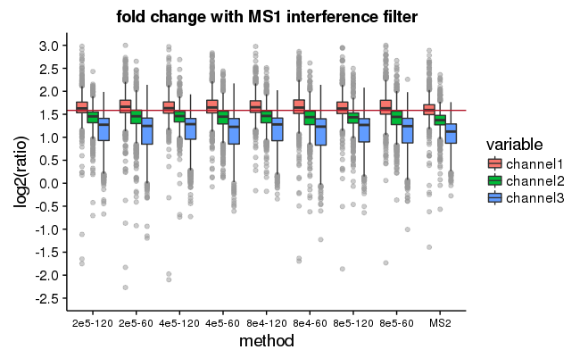

```r
id_quant = readRDS('/projects/ptx_analysis/chughes/projects-current/raw-quant/tmt-methods/Routput/tmt-method-testing-id-quant-ms3-ms2_data.rds')
spikes = subset(id_quant, grepl('SPIKE_PEPS', id_quant$species)) #keep only spike peptides
#now look at the quality of the ratios
spikes$channel1 = log2(spikes$tmt131C_intensity / spikes$tmt129N_intensity)
spikes$channel2 = log2(spikes$tmt131C_intensity / spikes$tmt129C_intensity)
spikes$channel3 = log2(spikes$tmt131C_intensity / spikes$tmt130N_intensity)
#make a boxplot of the spike data with different filters
#first do Isolation Interference
spikes_filt = subset(spikes, MS1Interference <= 50)
spike_plot = ggplot(melt(spikes_filt[,c(2,43:45)]), aes(fraction,value)) +
  geom_boxplot(aes(fill=variable), outlier.color = 'gray60',outlier.alpha=0.5) +
  theme(axis.text.x = element_text(size = 9)) +
  labs(x = "method", y = 'log2(ratio)', title = 'fold change with MS1 interference filter') +
  geom_hline(yintercept=log2(3),color=brewer.pal(6,'RdBu')[1]) +
  scale_y_continuous(limits=c(-2.5,3), breaks=seq(-2.5,3,0.5))
spike_plot #call the plot
save_plot('/projects/ptx_analysis/chughes/projects-current/raw-quant/tmt-methods/Routput/tmt-methods_spike-ratios-boxplot_ms1-interference-filter.pdf',spike_plot) #save the plot
```

```r
message(nrow(spikes_filt),' values remaining after filter.')
```

```
12076 values remaining after filter.
```

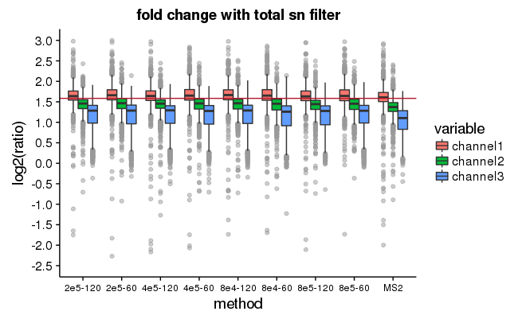

```r
#now do total signal to noise across all channels
spikes_filt = subset(spikes, totalSN >= 100)
spike_plot = ggplot(melt(spikes_filt[,c(2,43:45)]), aes(fraction,value)) +
  geom_boxplot(aes(fill=variable), outlier.color = 'gray60',outlier.alpha=0.5) +
  theme(axis.text.x = element_text(size = 9)) +
  labs(x = "method", y = 'log2(ratio)', title = 'fold change with total sn filter') +
  geom_hline(yintercept=log2(3),color=brewer.pal(6,'RdBu')[1]) +
  scale_y_continuous(limits=c(-2.5,3), breaks=seq(-2.5,3,0.5))
spike_plot #call the plot
save_plot('/projects/ptx_analysis/chughes/projects-current/raw-quant/tmt-methods/Routput/tmt-methods_spike-ratios-boxplot_total-sn-filter.pdf',spike_plot) #save the plot
```

```r
message(nrow(spikes_filt),' values remaining after filter.')
```

```
14869 values remaining after filter.
```

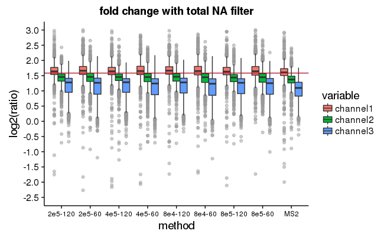

```r
#now do number of missing values across channels
spikes_filt = subset(spikes, totalNA <= 5)
spike_plot = ggplot(melt(spikes_filt[,c(2,43:45)]), aes(fraction,value)) +
  geom_boxplot(aes(fill=variable), outlier.color = 'gray60',outlier.alpha=0.5) +
  theme(axis.text.x = element_text(size = 9)) +
  labs(x = "method", y = 'log2(ratio)', title = 'fold change with total NA filter') +
  geom_hline(yintercept=log2(3),color=brewer.pal(6,'RdBu')[1]) +
  scale_y_continuous(limits=c(-2.5,3), breaks=seq(-2.5,3,0.5))
spike_plot #call the plot
save_plot('/projects/ptx_analysis/chughes/projects-current/raw-quant/tmt-methods/Routput/tmt-methods_spike-ratios-boxplot_total-na-filter.pdf',spike_plot) #save the plot
```

```r
message(nrow(spikes_filt),' values remaining after filter.')
```

```
15992 values remaining after filter.
```

None of the filters seem to make any difference across the methods. Can we plot this differently to visualize it better?

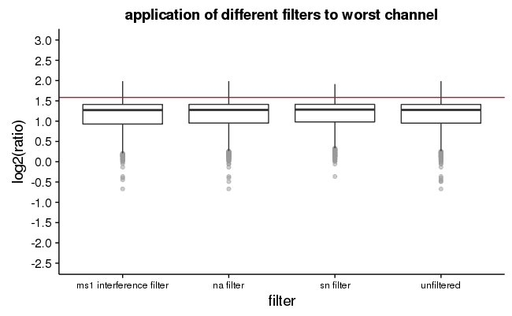

```r
id_quant = readRDS('/projects/ptx_analysis/chughes/projects-current/raw-quant/tmt-methods/Routput/tmt-method-testing-id-quant-ms3-ms2_data.rds')
spikes = subset(id_quant, grepl('SPIKE_PEPS', id_quant$species) & grepl('2e5-120', id_quant$fraction)) #keep only spike peptides
#now look at the quality of the ratios
spikes$channel1 = log2(spikes$tmt131C_intensity / spikes$tmt129N_intensity)
spikes$channel2 = log2(spikes$tmt131C_intensity / spikes$tmt129C_intensity)
spikes$channel3 = log2(spikes$tmt131C_intensity / spikes$tmt130N_intensity)
#make a boxplot of the spike data with different filters all on one plot
spikes_ms1 = subset(spikes, MS1Interference <= 50)
spikes_sn = subset(spikes, totalSN >= 100)
spikes_na = subset(spikes, totalNA <= 5)
#add a category column for each of them
spikes$dataset = 'unfiltered'
spikes_ms1$dataset = 'ms1 interference filter'
spikes_sn$dataset = 'sn filter'
spikes_na$dataset = 'na filter'
#bind all of the data togther
all_spikes = rbind(spikes, spikes_ms1, spikes_sn, spikes_na)
#now plot the data in a boxplot
filter_plot = ggplot(all_spikes, aes(dataset,channel3)) +
  geom_boxplot(outlier.color = 'gray60',outlier.alpha=0.5) +
  theme(axis.text.x = element_text(size = 9)) +
  labs(x = "filter", y = 'log2(ratio)', title = 'application of different filters to worst channel') +
  geom_hline(yintercept=log2(3),color=brewer.pal(6,'RdBu')[1]) +
  scale_y_continuous(limits=c(-2.5,3), breaks=seq(-2.5,3,0.5))
filter_plot #call the plot
save_plot('/projects/ptx_analysis/chughes/projects-current/raw-quant/tmt-methods/Routput/tmt-methods_data-filtering-MS3-boxplot.pdf',filter_plot) #save the plot
```

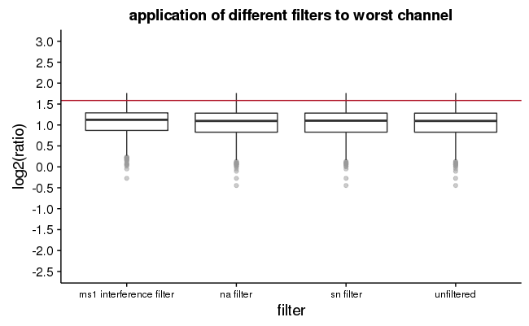

```r
####now do this for MS2
id_quant = readRDS('/projects/ptx_analysis/chughes/projects-current/raw-quant/tmt-methods/Routput/tmt-method-testing-id-quant-ms3-ms2_data.rds')
spikes = subset(id_quant, grepl('SPIKE_PEPS', id_quant$species) & grepl('MS2', id_quant$fraction)) #keep only spike peptides
#now look at the quality of the ratios
spikes$channel1 = log2(spikes$tmt131C_intensity / spikes$tmt129N_intensity)
spikes$channel2 = log2(spikes$tmt131C_intensity / spikes$tmt129C_intensity)
spikes$channel3 = log2(spikes$tmt131C_intensity / spikes$tmt130N_intensity)
#make a boxplot of the spike data with different filters all on one plot
spikes_ms1 = subset(spikes, MS1Interference <= 50)
spikes_sn = subset(spikes, totalSN >= 100)
spikes_na = subset(spikes, totalNA <= 5)
#add a category column for each of them
spikes$dataset = 'unfiltered'
spikes_ms1$dataset = 'ms1 interference filter'
spikes_sn$dataset = 'sn filter'
spikes_na$dataset = 'na filter'
#bind all of the data togther
all_spikes = rbind(spikes, spikes_ms1, spikes_sn, spikes_na)
#now plot the data in a boxplot
filter_plot = ggplot(all_spikes, aes(dataset,channel3)) +
  geom_boxplot(outlier.color = 'gray60',outlier.alpha=0.5) +
  theme(axis.text.x = element_text(size = 9)) +
  labs(x = "filter", y = 'log2(ratio)', title = 'application of different filters to worst channel') +
  geom_hline(yintercept=log2(3),color=brewer.pal(6,'RdBu')[1]) +
  scale_y_continuous(limits=c(-2.5,3), breaks=seq(-2.5,3,0.5))
filter_plot #call the plot
save_plot('/projects/ptx_analysis/chughes/projects-current/raw-quant/tmt-methods/Routput/tmt-methods_data-filtering-MS2-boxplot.pdf',filter_plot) #save the plot
```

So no real difference there…all of those filters are equally useless. So in MS2 it seems it is something you just have to accept, but I wonder if you can derive an MS2 interference score based on the SPS ions. RawQuant provides this data, so may be possible. Need to derive an MS3 quant set with the SPS ions first.

```r
all_ms3_quant = data.frame() #data storage object
#iterate over the files
for (i in 1:length(ms3_quant_files)){
####this second section handles the RawScan quantification data
  quant_in = read.table(ms3_quant_files[i],header=TRUE,sep='\t') #grab the input file
  quant_in[,11:96][quant_in[,11:96] == 0] = NA #transform any zero or missing values to NA
  quant_meta = quant_in[,c('PrecursorMass','ScanNumber','MS1ScanNumber','MS2ScanNumber','RetentionTime',
                           'PrecursorCharge','MS3IonInjectionTime','MS1Interference','tmt126_mass','tmt127N_mass',
                           'tmt127C_mass','tmt128N_mass','tmt128C_mass','tmt129N_mass','tmt129C_mass',
                           'tmt130N_mass','tmt130C_mass','tmt131N_mass','tmt131C_mass','SPSMass1','SPSMass2',
                           'SPSMass3','SPSMass4','SPSMass5','SPSMass6','SPSMass7','SPSMass8','SPSMass9','SPSMass10',
                           'SPSIntensity1','SPSIntensity2','SPSIntensity3','SPSIntensity4','SPSIntensity5','SPSIntensity6',
                           'SPSIntensity7','SPSIntensity8','SPSIntensity9','SPSIntensity10')] #extract the quantification meta data
  quant_exprs = quant_in[,c('tmt126_intensity','tmt127N_intensity','tmt127C_intensity','tmt128N_intensity',
                            'tmt128C_intensity','tmt129N_intensity','tmt129C_intensity','tmt130N_intensity',
                            'tmt130C_intensity','tmt131N_intensity','tmt131C_intensity','tmt126_noise','tmt127N_noise',
                            'tmt127C_noise','tmt128N_noise','tmt128C_noise','tmt129N_noise','tmt129C_noise','tmt130N_noise',
                            'tmt130C_noise','tmt131N_noise','tmt131C_noise')] #extract the quantification data
  quant_sn = quant_exprs[,c(1:11)] / quant_exprs[,c(12:22)] #signal-to-noise calculation
  quant_sn$totalIntensity = rowSums(quant_exprs[,1:11],na.rm=TRUE) #total intensity calculation
  quant_sn$totalSN = rowSums(quant_sn[,1:11],na.rm=TRUE) #total signal-to-noise calculation
  quant_sn$totalNoise = rowSums(quant_exprs[,12:22],na.rm=TRUE) #total noise calculation
  quant_sn$totalSPS = rowSums(quant_in[,87:96],na.rm=TRUE) #calculate the total sum SPS ion intensity
  quant_sn$SPScount = rowSums(!is.na(quant_in[,77:86])) #calculate the number of SPS ions selected
  quant_sn$totalNA = rowSums(is.na(quant_sn[,1:11])) #grab the number of NA values across the TMT channels
  quant_meta$fraction = sub(".*?TMT11_(.*?)_.*", "\\1", ms3_quant_files[i]) #add the fraction column
  quant_meta$replicate = sub(".*?TMT11_(.*?)_Quant.*", "\\1", ms3_quant_files[i]) #add a replicate column
  quant_matrix = cbind(quant_meta,quant_sn) #combined the meta and final expression data

  ####this section merges all of the data together
  all_ms3_quant = rbind(all_ms3_quant,quant_matrix) #merge with the ongiong data frame
  message('finished ',i,' files') #output message for tracking progress
}
saveRDS(all_ms3_quant,'/projects/ptx_analysis/chughes/projects-current/raw-quant/tmt-methods/Routput/tmt-method-testing-quant-ms3-only.rds') #save the data
```

Now we can interface with the b,y ion data from the search output.

```r
#need to use the ms3 ion match files here, but they are kind of weird. Will need to parse them into a usable object first.
#iterate over the meta files first
meta_set = data.frame() #data storage object
for (i in 1:length(ms3_ionmeta_files)){
  meta_in = read.table(ms3_ionmeta_files[i],header=TRUE,sep='\t') #read in the data
  colnames(meta_in) = c('Rank','Sequence','Spectrum.Title','Confidence','Validation','Spectrum')
  meta_in$Spectrum = row.names(meta_in) #grab the scan numbers
  meta_sub = subset(meta_in, (meta_in$Validation == 'Confident') & (meta_in$Rank == 1)) #filter out low quality hits
  meta_sub$Scan = sub(".*?spectrum (.*?)", "\\1", meta_sub$Spectrum.Title) #set the scan number
  meta_sub$fraction = sub(".*?TMT11_(.*?)_.*", "\\1", meta_sub$Spectrum.Title) #set the fraction
  meta_sub$replicate = sub(".*?TMT11_(.*?)\\.raw.*", "\\1", meta_sub$Spectrum.Title) #set the replicate

  #now process the ion files
  ions_in = read.table(ms3_ionsignal_files[i],header=FALSE,sep='\t',fill=TRUE,stringsAsFactors=FALSE)
  ions_in$Spectrum = sub("(.*?)\\..*", "\\1", ions_in[,1]) #parse out the spectrum
  ions_sub = subset(ions_in, Spectrum %in% meta_sub$Spectrum) #filter based on the quality in the meta data
  ions_sub2 = ions_sub[,c(1:6,8)] #select specific columns
  offset_spots = grepl('\\.',ions_sub2[,2]) #grab the offset column locations
  ions_sub2[offset_spots,2:5] = ions_sub2[offset_spots,3:6] #reposition the data in the offset spots
  ions_filtered = ions_sub2[,c(2:5,7)] #select specific columns
  colnames(ions_filtered) = c('Name','Mass','Intensity','Error','Spectrum') #rename the columns
  #bind the data together
  meta_ion_set = merge(ions_filtered, meta_sub[,c(6,1,2,4,5,7,8,9)], by='Spectrum',all.x=TRUE) #bind the data with the previous
  meta_set = rbind(meta_set, meta_ion_set)
}
saveRDS(meta_set, '/projects/ptx_analysis/chughes/projects-current/raw-quant/tmt-methods/Routput/tmt-method-testing-ms3-meta-data.rds')
```

The above commands are super slow because the ion files are huge. But, it works.

```r
#grab the quantification data
ms3_quant = readRDS('/projects/ptx_analysis/chughes/projects-current/raw-quant/tmt-methods/Routput/tmt-method-testing-quant-ms3-only.rds')
#grab the quantification data
ms3_ions = readRDS('/projects/ptx_analysis/chughes/projects-current/raw-quant/tmt-methods/Routput/tmt-method-testing-ms3-meta-data.rds')
ms3quant_sub = subset(ms3_quant, fraction == '2e5-120') #keep only the 2e5-120 replicates to match with the ion data
colnames(ms3_ions)[10] = 'MS2ScanNumber' #change the column name for merging
ms3_sps = merge(ms3_ions, ms3quant_sub, by=c('MS2ScanNumber','replicate')) #merge the data
ms3_sps$Mass = as.numeric(ms3_sps$Mass) #change the Mass to numeric
sps_matrix = as.data.frame(apply(ms3_sps[,c(31:40)],2, function(x) ((x >= ms3_sps$Mass - 0.5) & (x <= ms3_sps$Mass + 0.5)))) #make an SPS mass matrix
sps_matrix$sps_location = apply(sps_matrix[,1:10],1,function(x) which(x)) #get the location of the SPS hit
ms3_sps$sps_location = as.numeric(sps_matrix$sps_location) #add the location to the original data
ms3_sps_sub = subset(ms3_sps, !is.na(ms3_sps$sps_location)) #get rid of rows without a hit
#this command aggregates based on scan number and mass to remove redundant hits
ms3_sps_mass_agg <- setDT(ms3_sps_sub)[, lapply(.SD,mean,na.rm=TRUE),by=list(MS2ScanNumber,Mass,replicate),.SDcols=c('SPSIntensity1','SPSIntensity2',
                                                                                                           'SPSIntensity3','SPSIntensity4',
                                                                                                           'SPSIntensity5','SPSIntensity6',
                                                                                                           'SPSIntensity7','SPSIntensity8',
                                                                                                           'SPSIntensity9','SPSIntensity10',
                                                                                                           'sps_location','totalSPS')]
setDF(ms3_sps_mass_agg) # convert back to dataframe
ms3_sps_mass_agg$sps_intensity = 0 #add a column to deposit the intensity into
#this loops over the rows to grab the intensity...slow, but it works
for (i in 1:nrow(ms3_sps_mass_agg)){
  sps_location = ms3_sps_mass_agg[i,'sps_location'] + 3
  ms3_sps_mass_agg[i,16] = ms3_sps_mass_agg[i,sps_location]
}
#now we need to aggregate again, this time by the individual scan
ms3_sps_mass_agg$sps_count = 1 #add this counter so we can recalculate the total SPS intensity later on
sps_set <- setDT(ms3_sps_mass_agg)[,lapply(.SD,sum,na.rm=TRUE),by=list(MS2ScanNumber,replicate),.SDcols=c('totalSPS','sps_intensity','sps_count')]
setDF(sps_set) # convert back to dataframe
sps_set$totalSPS = sps_set$totalSPS / sps_set$sps_count #convert the total signal back to the original value
sps_set$sps_purity = ((sps_set$sps_intensity / sps_set$totalSPS) * 100) #calculate the purity
saveRDS(sps_set, '/projects/ptx_analysis/chughes/projects-current/raw-quant/tmt-methods/Routput/tmt-method-testing-sps-purity-set.rds') #output the data
```

Now we can look at how the SPS purity impacts the data.

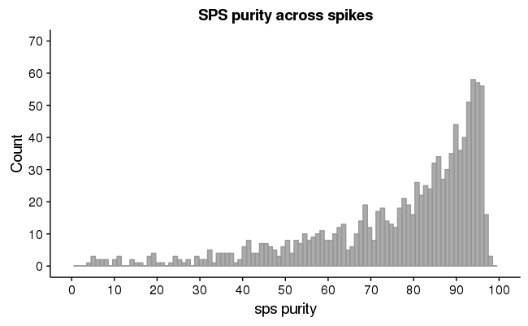

```r
sps = readRDS('/projects/ptx_analysis/chughes/projects-current/raw-quant/tmt-methods/Routput/tmt-method-testing-sps-purity-set.rds')
id_quant = readRDS('/projects/ptx_analysis/chughes/projects-current/raw-quant/tmt-methods/Routput/tmt-method-testing-id-quant-ms3-ms2_data.rds')
spikes = subset(id_quant, grepl('SPIKE_PEPS', id_quant$species) & grepl('2e5-120', id_quant$fraction)) #keep only spike peptides
spikes$channel3 = log2(spikes$tmt131C_intensity / spikes$tmt130N_intensity) #again use the most interfered with channel
spikes$difference = abs(log2(3) - spikes$channel3) #get the difference from expected
colnames(spikes)[1] = 'MS2ScanNumber'
spikes_sps = merge(sps,spikes,by=c('MS2ScanNumber','replicate'))
sps_dist = ggplot(spikes_sps, aes(sps_purity)) +
  geom_histogram(bins=100,colour = 'grey60',alpha = 0.5) +
  labs(x = "sps purity", y = 'Count', title = 'SPS purity across spikes') +
  scale_x_continuous(limits=c(0,100), breaks=seq(0,100,10)) +
  scale_y_continuous(limits=c(0,70), breaks=seq(0,70,10))
sps_dist #call the plot
save_plot('/projects/ptx_analysis/chughes/projects-current/raw-quant/tmt-methods/Routput/tmt-methods_sps-purity-distribution.pdf',sps_dist) #save the plot
```

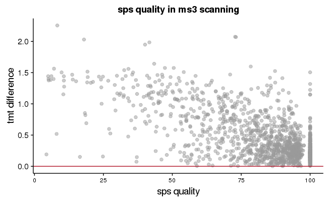

```r
#plot the SPS quality vs the ratio
sps_quality = ggplot(spikes_sps, aes(sps_purity,difference)) +
  geom_point(size=2,alpha=0.5,colour='grey60') +
  theme(axis.text.x = element_text(size = 9)) +
  labs(x = "sps quality", y = 'tmt difference', title = 'sps quality in ms3 scanning') +
  geom_hline(yintercept = 0,color=brewer.pal(6,'RdBu')[1])
sps_quality #call the plot
save_plot('/projects/ptx_analysis/chughes/projects-current/raw-quant/tmt-methods/Routput/tmt-methods_SPS-quality-channel3.pdf',sps_quality) #save the plot
```

```r
message(cor(spikes_sps$sps_purity,spikes_sps$difference,use='pairwise.complete.obs'),' in ms3')
```

```
-0.662060201193258 in ms3
```

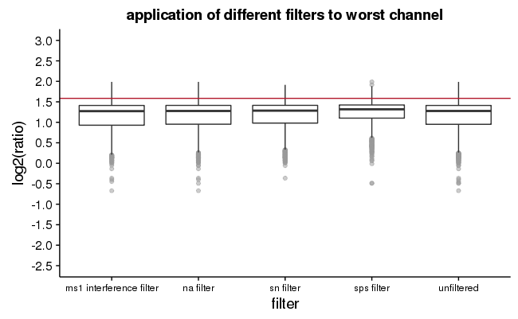

```r
#make a boxplot of the spike data with different filters all on one plot
spikes_ms1 = subset(spikes, MS1Interference <= 50)
spikes_sn = subset(spikes, totalSN >= 100)
spikes_na = subset(spikes, totalNA <= 5)
spikes_sps = subset(spikes_sps, sps_purity >= 60)
#add a category column for each of them
spikes$dataset = 'unfiltered'
spikes_ms1$dataset = 'ms1 interference filter'
spikes_sn$dataset = 'sn filter'
spikes_na$dataset = 'na filter'
spikes_sps$dataset = 'sps filter'
#bind all of the data togther
all_spikes = rbind(spikes[,c(43,45)], spikes_ms1[,c(43,45)], spikes_sn[,c(43,45)], spikes_na[,c(43,45)], spikes_sps[,c(47,49)])
#now plot the data in a boxplot
filter_plot = ggplot(all_spikes, aes(dataset,channel3)) +
  geom_boxplot(outlier.color = 'gray60',outlier.alpha=0.5) +
  theme(axis.text.x = element_text(size = 9)) +
  labs(x = "filter", y = 'log2(ratio)', title = 'application of different filters to worst channel') +
  geom_hline(yintercept=log2(3),color=brewer.pal(6,'RdBu')[1]) +
  scale_y_continuous(limits=c(-2.5,3), breaks=seq(-2.5,3,0.5))
filter_plot #call the plot
save_plot('/projects/ptx_analysis/chughes/projects-current/raw-quant/tmt-methods/Routput/tmt-methods_data-filtering-boxplot-with-SPS.pdf',filter_plot) #save the plot
```

One last thing it would be nice to look at is ion coalescence. We have the mass data, so this is do-able.

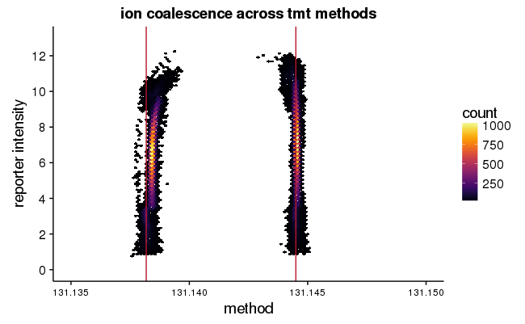

```r
q_set = readRDS('/projects/ptx_analysis/chughes/projects-current/raw-quant/tmt-methods/Routput/tmt-method-testing-quant-data_no-sps.rds') #grab the quantification data
reporter1 = q_set[,c('tmt131N_mass','tmt131N_intensity','fraction')] #grab the first reporter you want to look at
reporter2 = q_set[,c('tmt131C_mass','tmt131C_intensity','fraction')] #grab the second reporter you want to look at
colnames(reporter1) = c('mass','intensity','fraction') #change the column names for merging
colnames(reporter2) = c('mass','intensity','fraction') #change the column names for merging
reporter_all = rbind(reporter1,reporter2) #bind the data together
reporter_all = subset(reporter_all, !is.na(reporter_all$mass)) #remove rows with nor reported values
reporter_all = subset(reporter_all, fraction == 'MS2') #choose the fraction you wish to look at
#plot the data
ionc_plot = ggplot(reporter_all, aes(mass,log2(intensity))) +
  geom_hex(bins=100,alpha=1) +
  theme(axis.text.x = element_text(size = 9)) +
  labs(x = "method", y = 'reporter intensity', title = 'ion coalescence across tmt methods') +
  #geom_vline(xintercept = 129.131471,color=brewer.pal(6,'RdBu')[1]) +
  #geom_vline(xintercept = 129.137790,color=brewer.pal(6,'RdBu')[1]) +
  #geom_vline(xintercept = 130.134825,color=brewer.pal(6,'RdBu')[1]) +
  #geom_vline(xintercept = 130.141145,color=brewer.pal(6,'RdBu')[1]) +
  geom_vline(xintercept = 131.138180,color=brewer.pal(6,'RdBu')[1]) +
  geom_vline(xintercept = 131.144499,color=brewer.pal(6,'RdBu')[1]) +
  scale_y_continuous(limits=c(0,13),breaks=seq(0,14,2)) +
  #scale_x_continuous(limits=c(129.125,129.145)) +
  #scale_x_continuous(limits=c(130.130,130.145)) +
  scale_x_continuous(limits=c(131.135,131.150)) +
  scale_fill_viridis(option='inferno')
ionc_plot #call the plot
save_plot('/projects/ptx_analysis/chughes/projects-current/raw-quant/tmt-methods/Routput/tmt-methods_ion-coalescence-MS2_TMT131.pdf',ionc_plot) #save the plot
```

Want to lastly look at how well the signal-to-noise and intensity measurements match up for the synthetic peptides.

```r
ms3_id_quant = data.frame() #ms3 data storage object
ms2_id_quant = data.frame() #ms2 data storage object
#iterate over the ms3 files
for (i in 1:length(ms3_psm_files)){
###this first section handles the identification data
  psm_in = read.table(ms3_psm_files[i],header=TRUE,sep='\t') #input file
  psm_f1 = psm_in %>%
    dplyr::select(Protein.s., Sequence, Spectrum.File, Spectrum.Title, m.z, Identification.Charge) %>% #select columns
    dplyr::mutate(Spectrum.Title, scan_num = sub(".*?spectrum (.*?)", "\\1", Spectrum.Title)) %>% #parse out the scan number
    dplyr::mutate(Identification.Charge, id_charge = gsub("[^0-9]", "", Identification.Charge)) %>% #parse out the charge
    dplyr::mutate(Spectrum.Title, fraction = sub(".*?TMT11_(.*?)_.*", "\\1", Spectrum.File)) %>% #parse the fraction
    dplyr::mutate(Spectrum.Title, replicate = sub(".*?TMT11_(.*?)_MGF\\.mgf", "\\1", Spectrum.File)) %>% #parse the fraction
    dplyr::select(Protein.s., Sequence, scan_num, m.z, id_charge, fraction, replicate) %>% #select new columns
    dplyr::mutate(Protein.s., first_accession = sapply(strsplit(as.character(Protein.s.),"\\,"), `[`, 1)) #parse the accession
  #adjust the column names
  colnames(psm_f1) = c('accession_groups','sequence','ScanNumber','id_precursor_mz','id_charge','fraction','replicate','accession')
  psm_f2 = merge(psm_f1,ecoliIndex,by='accession',all.x=TRUE) #add the descriptive data
  psm_f3 = dplyr::filter(psm_f2, !grepl('CONT', accession)) #remove contaminant hits

  ####this second section handles the RawScan quantification data
  quant_in = read.table(ms3_quant_files[i],header=TRUE,sep='\t') #grab the input file
  quant_in[,11:96][quant_in[,11:96] == 0] = NA
  #rearrange the data frame
  quant_meta = quant_in[,c('PrecursorMass','MS2ScanNumber','MS1ScanNumber','RetentionTime',
                           'PrecursorCharge','MS2IonInjectionTime','MS1Interference',
                           'tmt126_mass','tmt127N_mass','tmt127C_mass','tmt128N_mass','tmt128C_mass','tmt129N_mass','tmt129C_mass',
                           'tmt130N_mass','tmt130C_mass','tmt131N_mass','tmt131C_mass')]
  colnames(quant_meta)[2] = 'ScanNumber'
  quant_exprs = quant_in[,c('tmt126_intensity','tmt127N_intensity','tmt127C_intensity','tmt128N_intensity',
                            'tmt128C_intensity','tmt129N_intensity','tmt129C_intensity','tmt130N_intensity',
                            'tmt130C_intensity','tmt131N_intensity','tmt131C_intensity','tmt126_noise','tmt127N_noise',
                            'tmt127C_noise','tmt128N_noise','tmt128C_noise','tmt129N_noise','tmt129C_noise','tmt130N_noise',
                            'tmt130C_noise','tmt131N_noise','tmt131C_noise')]
  #calculate signal to noise
  quant_sn = quant_exprs[,c(1:11)] / quant_exprs[,c(12:22)] #signal-to-noise calculation
  quant_sn$totalIntensity = rowSums(quant_exprs[,1:11],na.rm=TRUE) #total intensity calculation
  quant_sn$totalSN = rowSums(quant_sn[,1:11],na.rm=TRUE) #total signal-to-noise calculation
  quant_sn$totalNoise = rowSums(quant_exprs[,12:22],na.rm=TRUE) #total noise calculation
  quant_sn$totalNA = rowSums(is.na(quant_sn[,1:11])) #information about missing values
  quant_meta$fraction = sub(".*?TMT11_(.*?)_.*", "\\1", ms3_quant_files[i]) #add the fraction column
  quant_meta$replicate = sub(".*?TMT11_(.*?)_Quant.*", "\\1", ms3_quant_files[i]) #add a replicate column
  quant_matrix = cbind(quant_meta,quant_sn,quant_exprs) #bind the information and quantification together
  ####this section merges all of the data together
  quant_id = merge(psm_f3,quant_matrix,by=c('ScanNumber','fraction','replicate'),all.x=TRUE) #merge the id and quant data
  ms3_id_quant = rbind(ms3_id_quant,quant_id) #merge with the ongiong data frame
  message('finished ',i,' ms3 files') #output message for tracking progress
}
#iterate over the ms2 files
for (i in 1:length(ms2_psm_files)){
###this first section handles the identification data
  psm_in = read.table(ms2_psm_files[i],header=TRUE,sep='\t') #input file
  psm_f1 = psm_in %>%
    dplyr::select(Protein.s., Sequence, Spectrum.File, Spectrum.Title, m.z, Identification.Charge) %>% #select columns
    dplyr::mutate(Spectrum.Title, scan_num = sub(".*?spectrum (.*?)", "\\1", Spectrum.Title)) %>% #parse out the scan number
    dplyr::mutate(Identification.Charge, id_charge = gsub("[^0-9]", "", Identification.Charge)) %>% #parse out the charge
    dplyr::mutate(Spectrum.Title, fraction = sub(".*?TMT11_(.*?)_.*", "\\1", Spectrum.File)) %>% #parse the fraction
    dplyr::mutate(Spectrum.Title, replicate = sub(".*?TMT11_(.*?)_MGF\\.mgf", "\\1", Spectrum.File)) %>% #parse the fraction
    dplyr::select(Protein.s., Sequence, scan_num, m.z, id_charge, fraction, replicate) %>% #select new columns
    dplyr::mutate(Protein.s., first_accession = sapply(strsplit(as.character(Protein.s.),"\\,"), `[`, 1)) #parse the accession
  #adjust the column names
  colnames(psm_f1) = c('accession_groups','sequence','ScanNumber','id_precursor_mz','id_charge','fraction','replicate','accession')
  psm_f2 = merge(psm_f1,ecoliIndex,by='accession',all.x=TRUE) #add the descriptive data
  psm_f3 = dplyr::filter(psm_f2, !grepl('CONT', accession)) #remove contaminant hits

  ####this second section handles the RawScan quantification data
  quant_in = read.table(ms2_quant_files[i],header=TRUE,sep='\t') #grab the input file
  quant_in[,9:74][quant_in[,9:74] == 0] = NA
  #rearrange the data frame
  quant_meta = quant_in[,c('PrecursorMass','ScanNumber','MS1ScanNumber','RetentionTime',
                           'PrecursorCharge','MS2IonInjectionTime','MS1Interference',
                           'tmt126_mass','tmt127N_mass','tmt127C_mass','tmt128N_mass','tmt128C_mass','tmt129N_mass','tmt129C_mass',
                           'tmt130N_mass','tmt130C_mass','tmt131N_mass','tmt131C_mass')]
  quant_exprs = quant_in[,c('tmt126_intensity','tmt127N_intensity','tmt127C_intensity','tmt128N_intensity',
                            'tmt128C_intensity','tmt129N_intensity','tmt129C_intensity','tmt130N_intensity',
                            'tmt130C_intensity','tmt131N_intensity','tmt131C_intensity','tmt126_noise','tmt127N_noise',
                            'tmt127C_noise','tmt128N_noise','tmt128C_noise','tmt129N_noise','tmt129C_noise','tmt130N_noise',
                            'tmt130C_noise','tmt131N_noise','tmt131C_noise')]
  #calculate signal to noise
  quant_sn = quant_exprs[,c(1:11)] / quant_exprs[,c(12:22)] #signal-to-noise calculation
  quant_sn$totalIntensity = rowSums(quant_exprs[,1:11],na.rm=TRUE) #total intensity calculation
  quant_sn$totalSN = rowSums(quant_sn[,1:11],na.rm=TRUE) #total signal-to-noise calculation
  quant_sn$totalNoise = rowSums(quant_exprs[,12:22],na.rm=TRUE) #total noise calculation
  quant_sn$totalNA = rowSums(is.na(quant_sn[,1:11])) #information about missing values
  quant_meta$fraction = sub(".*?TMT11_(.*?)_.*", "\\1", ms2_quant_files[i]) #add the fraction column
  quant_meta$replicate = sub(".*?TMT11_(.*?)_Quant.*", "\\1", ms2_quant_files[i]) #add a replicate column
  quant_matrix = cbind(quant_meta,quant_sn,quant_exprs) #bind the information and quantification together
  ####this section merges all of the data together
  quant_id = merge(psm_f3,quant_matrix,by=c('ScanNumber','fraction','replicate'),all.x=TRUE) #merge the id and quant data
  ms2_id_quant = rbind(ms2_id_quant,quant_id) #merge with the ongiong data frame
  message('finished ',i,' ms2 files') #output message for tracking progress
}
ms3_ms2_all = rbind(ms3_id_quant,ms2_id_quant) #bind the data together
saveRDS(ms3_ms2_all,'/projects/ptx_analysis/chughes/projects-current/raw-quant/tmt-methods/Routput/tmt-method-testing-id-quant-ms3-ms2_data_withIntensities.rds') #save the data
```

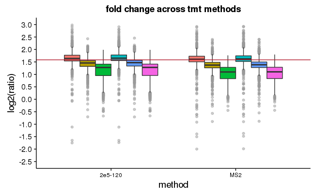

```r
id_quant = readRDS('/projects/ptx_analysis/chughes/projects-current/raw-quant/tmt-methods/Routput/tmt-method-testing-id-quant-ms3-ms2_data_withIntensities.rds')
#now look at the quality of the ratios
spikes = subset(id_quant, grepl('SPIKE_PEPS', id_quant$species) & grepl('2e5-120', id_quant$fraction) |  grepl('SPIKE_PEPS', id_quant$species) & grepl('MS2', id_quant$fraction)) #keep only spike peptides
spikes$channel1_s2n = log2(spikes$tmt131C_intensity / spikes$tmt129N_intensity)
spikes$channel2_s2n = log2(spikes$tmt131C_intensity / spikes$tmt129C_intensity)
spikes$channel3_s2n = log2(spikes$tmt131C_intensity / spikes$tmt130N_intensity)
spikes$channel1_int = log2(spikes$tmt131C_intensity.1 / spikes$tmt129N_intensity.1)
spikes$channel2_int = log2(spikes$tmt131C_intensity.1 / spikes$tmt129C_intensity.1)
spikes$channel3_int = log2(spikes$tmt131C_intensity.1 / spikes$tmt130N_intensity.1)
#make a boxplot of the spike data
spike_plot = ggplot(melt(spikes[,c(2,65:70)]), aes(fraction,value)) +
  geom_boxplot(aes(fill=variable), outlier.color = 'gray60',outlier.alpha=0.5) +
  theme(axis.text.x = element_text(size = 9)) +
  labs(x = "method", y = 'log2(ratio)', title = 'fold change across tmt methods') +
  geom_hline(yintercept=log2(3),color=brewer.pal(6,'RdBu')[1]) +
  scale_y_continuous(limits=c(-2.5,3), breaks=seq(-2.5,3,0.5)) +
  theme(legend.position="none")
spike_plot #call the plot
save_plot('/projects/ptx_analysis/chughes/projects-current/raw-quant/tmt-methods/Routput/tmt-methods_spike-ratios-with-intensities-boxplot.pdf',spike_plot) #save the plot
```

```r
#what is the correlation
cor(spikes[,c(65:70)],use='pairwise.complete.obs',method='pearson')
```

```
             channel1_s2n channel2_s2n channel3_s2n channel1_int channel2_int channel3_int
channel1_s2n    1.0000000    0.5470284    0.1218212    0.9990588    0.5455465    0.1215326
channel2_s2n    0.5470284    1.0000000    0.6537361    0.5469380    0.9986490    0.6534945
channel3_s2n    0.1218212    0.6537361    1.0000000    0.1223730    0.6535566    0.9997026
channel1_int    0.9990588    0.5469380    0.1223730    1.0000000    0.5477301    0.1230180
channel2_int    0.5455465    0.9986490    0.6535566    0.5477301    1.0000000    0.6544258
channel3_int    0.1215326    0.6534945    0.9997026    0.1230180    0.6544258    1.0000000
```

Done.